# ME - GIA. Introduccio MLGz (Covariables)

2024-09-17

## Introducció

En un estudi per estudiar el nivell de colesterol en sang, en persones en edat de creixement (9-20 anys), s’ha plantejat un model per explicar el nivell de colesterol (*C*) en funció del pes (*P*), edat (*E*) i alçada (*H*).

**És conegut que el pes és un dels factors que influeixen en l’augment del** **nivell de colesterol**

En aquest script es veuen els següents conceptes:

- Model lineal general com **cas particular** del model lineal generalitzat
- Com fer la **validació** del model lineal generalitzat
- Com fer **prediccions** amb bandes de predicció
- Com afecta la **funció link** i la **familia** a l’ajust

## Descriptiva prèvia

**Colesterol en funció de l’excés de pes ajustat per l’edat**

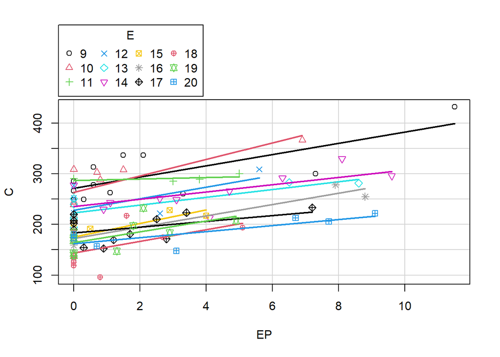

```r
scatterplot(C ~ EP|E,smooth=F,boxplots=F,col=1:12,dd)
```

**Colesterol en funció de l’edat**

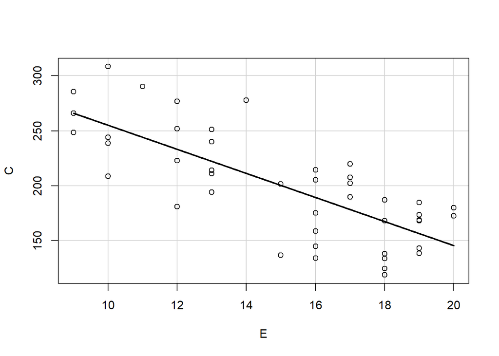

```r
scatterplot(C ~ E,   smooth=F,boxplots=F,col=1:12,dd[dd$EP==0,]) # Els que no tenen exces de pes
```

## Model lineal general com cas particular del model lineal generalitzat

En aquest apartat veurem com el Model lineal general (MLG) és un cas particular del model lineal generalitzat (MGLz) i que tot el que obtenim d’un és igual a l’altre. Començarem ajustant el model nul i el model amb *E* i *EP* emprant `lm` (MLG) i `glm` (MLGz).

```r
# Models nuls
mod0  <-  lm(C ~ 1, dd)
modg0 <- glm(C ~ 1, dd, family = gaussian(link=identity))

# Models amb exces de pes i edat
mod   <-  lm(C ~ EP + E, dd)
modg  <- glm(C ~ EP + E, dd, family = gaussian(link=identity))
```

**Comparativa dels coeficients dels models nuls**

Observem que els models nuls són el mateix model.

```r
# Models nuls
summary(mod0)
```

```
##
## Call:
## lm(formula = C ~ 1, data = dd)
##
## Residuals:
##      Min       1Q   Median       3Q      Max
## -128.569  -45.451   -7.319   44.449  207.931
##
## Coefficients:
##             Estimate Std. Error t value Pr(>|t|)
## (Intercept)  224.359      6.116   36.68   <2e-16 ***
## ---
## Signif. codes:  0 '***' 0.001 '**' 0.01 '*' 0.05 '.' 0.1 ' ' 1
##
## Residual standard error: 61.16 on 99 degrees of freedom
```

```r
summary(modg0)
```

```
##
## Call:
## glm(formula = C ~ 1, family = gaussian(link = identity), data = dd)
##
## Coefficients:
##             Estimate Std. Error t value Pr(>|t|)
## (Intercept)  224.359      6.116   36.68   <2e-16 ***
## ---
## Signif. codes:  0 '***' 0.001 '**' 0.01 '*' 0.05 '.' 0.1 ' ' 1
##
## (Dispersion parameter for gaussian family taken to be 3741.115)
##
##     Null deviance: 370370  on 99  degrees of freedom
## Residual deviance: 370370  on 99  degrees of freedom
## AIC: 1109.5
##
## Number of Fisher Scoring iterations: 2
```

**Comparativa dels coeficients dels models ajustats**

Observem que els models amb les variables explicatives són el mateix model.

```r
# Models ajustats
summary(mod)
```

```
##
## Call:
## lm(formula = C ~ EP + E, data = dd)
##
## Residuals:
##     Min      1Q  Median      3Q     Max
## -74.838 -21.208   1.658  20.369  65.293
##
## Coefficients:
##             Estimate Std. Error t value Pr(>|t|)
## (Intercept) 386.8560    12.9274  29.925  < 2e-16 ***
## EP            9.9347     1.0573   9.397 2.69e-15 ***
## E           -12.4542     0.8379 -14.863  < 2e-16 ***
## ---
## Signif. codes:  0 '***' 0.001 '**' 0.01 '*' 0.05 '.' 0.1 ' ' 1
##
## Residual standard error: 29.93 on 97 degrees of freedom
## Multiple R-squared:  0.7654, Adjusted R-squared:  0.7606
## F-statistic: 158.2 on 2 and 97 DF,  p-value: < 2.2e-16
```

```r
summary(modg)
```

```
##
## Call:
## glm(formula = C ~ EP + E, family = gaussian(link = identity),
##     data = dd)
##
## Coefficients:
##             Estimate Std. Error t value Pr(>|t|)
## (Intercept) 386.8560    12.9274  29.925  < 2e-16 ***
## EP            9.9347     1.0573   9.397 2.69e-15 ***
## E           -12.4542     0.8379 -14.863  < 2e-16 ***
## ---
## Signif. codes:  0 '***' 0.001 '**' 0.01 '*' 0.05 '.' 0.1 ' ' 1
##
## (Dispersion parameter for gaussian family taken to be 895.7749)
##
##     Null deviance: 370370  on 99  degrees of freedom
## Residual deviance:  86890  on 97  degrees of freedom
## AIC: 968.51
##
## Number of Fisher Scoring iterations: 2
```

**Comparativa dels VIFs**

Les col·linealitats també coincideixen

```r
vif(mod)
```

```
##       EP        E
## 1.000639 1.000639
```

```r
vif(modg)
```

```
##       EP        E
## 1.000639 1.000639
```

**Comparativa del test Omnibus**

Els tests omnibus també coincideixen

```r
anova(mod0, mod)
```

```
## Analysis of Variance Table
##
## Model 1: C ~ 1
## Model 2: C ~ EP + E
##   Res.Df    RSS Df Sum of Sq      F    Pr(>F)
## 1     99 370370
## 2     97  86890  2    283480 158.23 < 2.2e-16 ***
## ---
## Signif. codes:  0 '***' 0.001 '**' 0.01 '*' 0.05 '.' 0.1 ' ' 1
```

```r
anova(modg0,modg,test="F")
```

```
## Analysis of Deviance Table
##
## Model 1: C ~ 1
## Model 2: C ~ EP + E
##   Resid. Df Resid. Dev Df Deviance      F    Pr(>F)
## 1        99     370370
## 2        97      86890  2   283480 158.23 < 2.2e-16 ***
## ---
## Signif. codes:  0 '***' 0.001 '**' 0.01 '*' 0.05 '.' 0.1 ' ' 1
```

**Paràmetre de dispersió**

La teoria ens diu que el paràmetre de dispersió del MLGz és la $\sigma^2$ (variància residual) del MLG.

```r
summary(modg)$dispersion
```

```
## [1] 895.7749
```

```r
summary(mod)$sigma^2
```

```
## [1] 895.7749
```

**Comparativa de les prediccions**

Coincideixen els valors predits entre MLG i MLGz (tant tipus response com link)

```r
pr_lm      <- predict(mod)                      # predict MLG
pr_lm_resp <- predict(modg, type = "response")  # predict mu
pr_lm_link <- predict(modg, type = "link")      # predict eta (quan link=identity --> eta=mu)

summary(pr_lm_resp - pr_lm)
```

```
##    Min. 1st Qu.  Median    Mean 3rd Qu.    Max.
##       0       0       0       0       0       0
```

```r
summary(pr_lm_link - pr_lm)
```

```
##    Min. 1st Qu.  Median    Mean 3rd Qu.    Max.
##       0       0       0       0       0       0
```

**Comparativa dels residus**

Coincideixen tots els residus (per ser família normal)

```r
pr_raw      <- residuals(modg,type = "response") # residus crus
pr_pearson  <- residuals(modg,type = "pearson")  # residus pearson
pr_deviance <- residuals(modg,type = "deviance") # residus deviance
summary(pr_raw - pr_pearson)
```

```
##    Min. 1st Qu.  Median    Mean 3rd Qu.    Max.
##       0       0       0       0       0       0
```

```r
summary(pr_raw - pr_deviance)
```

```
##    Min. 1st Qu.  Median    Mean 3rd Qu.    Max.
##       0       0       0       0       0       0
```

## Validació del Model lineal generalitzat

Emprem el gràfic de residus versus valors predits.

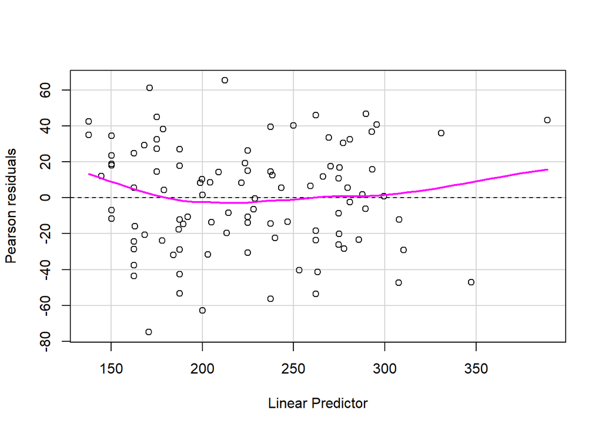

```r
# Plot residuals versus fitted
residualPlot(modg)
```

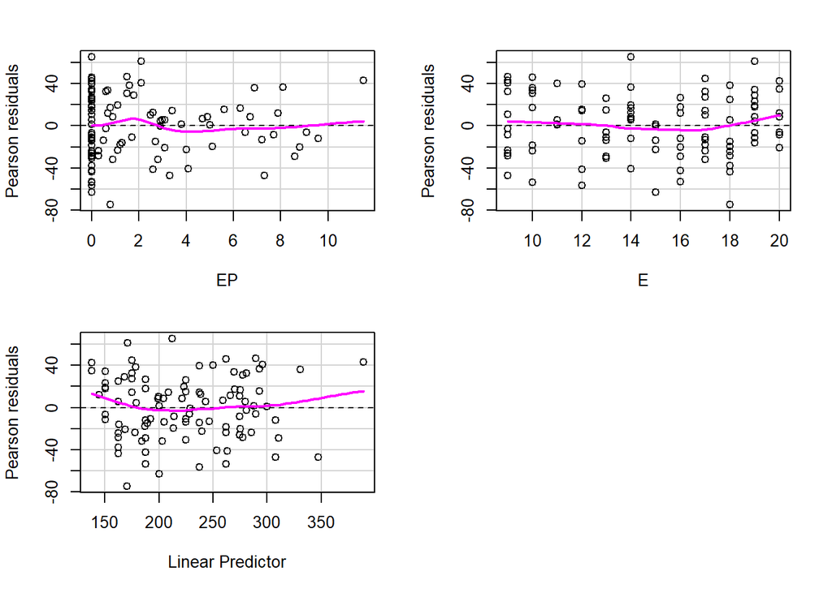

[output not shown]

```r
residualPlots(modg)
```

### Valors estranys

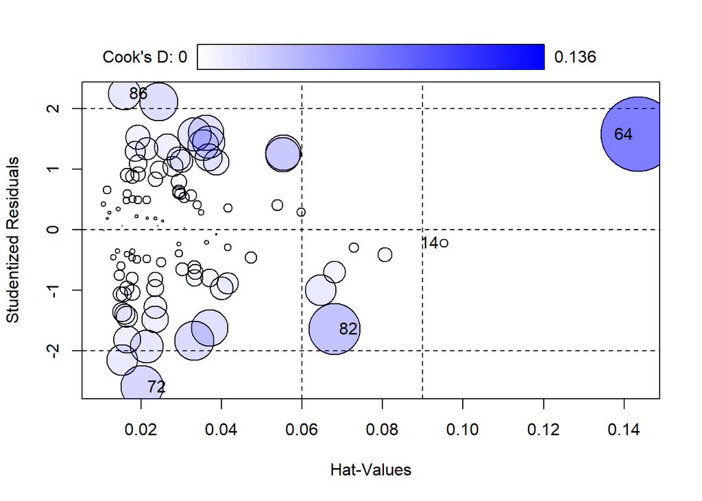

```
##       StudRes        Hat      CookD
## 14 -0.2232843 0.09521402 0.00176614
## 64  1.5741002 0.14350443 0.13630667
## 72 -2.6002364 0.02033048 0.04414839
## 82 -1.6408405 0.06801749 0.06437430
## 86  2.2443917 0.01588853 0.02602589
```

```r
influencePlot(model = modg)
```

## Predicció

Per les següents persones:

- EP=0 ; E=15
- EP=5 ; E=15

Trobem el interval de confiança del 95%.

```r
# Calcul del IC95% "manual"
pred <- predict(modg, data.frame(EP=c(0,5), E=c(15,15)), se.fit = T, type = "response")
cbind(pred$fit,
      pred$fit + qnorm(0.025) * pred$se.fit,
      pred$fit + qnorm(0.975) * pred$se.fit)
```

```
##       [,1]     [,2]     [,3]
## 1 200.0430 192.7504 207.3356
## 2 249.7167 241.2730 258.1603
```

```r
# Calcul del IC95% emprant funcio predict sobre model lineal
predict(mod,data.frame(EP=c(0,5),E=c(15,15)),interval="confidence")
```

```
##        fit      lwr      upr
## 1 200.0430 192.6582 207.4278
## 2 249.7167 241.1664 258.2669
```

Trobem el pseudo-interval de prediccio del 95% i el interval de prediccio assimptòtic (en el cas de la Normal, són equivalents).

```r
# pseudo-interval
cbind(pred$fit,
      pred$fit - 2 * pred$residual.scale,
      pred$fit + 2 * pred$residual.scale)
```

```
##       [,1]     [,2]     [,3]
## 1 200.0430 140.1840 259.9020
## 2 249.7167 189.8577 309.5756
```

```r
# asimptotic
cbind(pred$fit,
      qnorm(0.025, pred$fit, pred$residual.scale),
      qnorm(0.975, pred$fit, pred$residual.scale))
```

```
##       [,1]     [,2]     [,3]
## 1 200.0430 141.3823 258.7037
## 2 249.7167 191.0559 308.3774
```

## Funció link i Familia

### Link identitat i familia Normal

La validació del model no és molt deficient però tampoc és òptima.

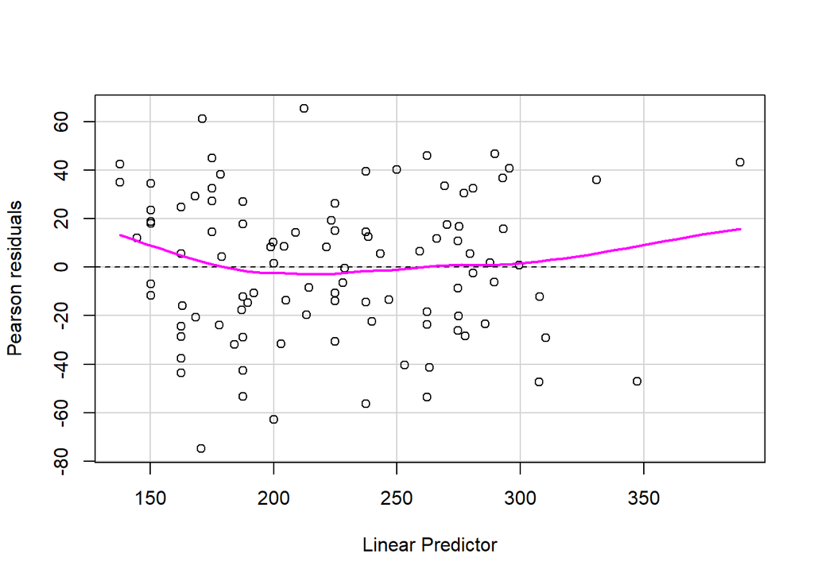

```r
residualPlot(modg)
```

### Altres funcions link

Com el que falla és la tendència central, hem de provar altre funcions links.

```r
modg_inv  <- glm(C ~ EP + E, dd, family = gaussian(link="inverse"))
modg_inv2 <- glm(C ~ EP + E, dd, family = gaussian(link="1/mu^2"))
modg_log  <- glm(C ~ EP + E, dd, family = gaussian(link="log"))
```

Veiem el gràfic de rsidus versus valors predits dels 4 links.

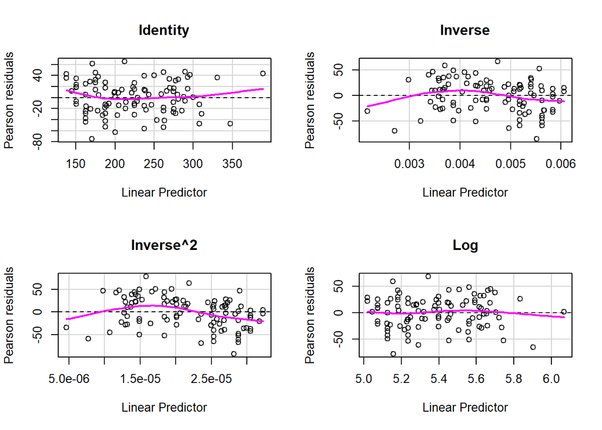

```r
par(mfrow=c(2,2))
residualPlot(modg ,    main='Identity')
residualPlot(modg_inv, main='Inverse')
residualPlot(modg_inv2,main='Inverse^2')
residualPlot(modg_log, main='Log')
```

Sembla que la funció link *log*, millora una mica la tendencia central. Comparem les prediccions del model amb link log i link identitat.

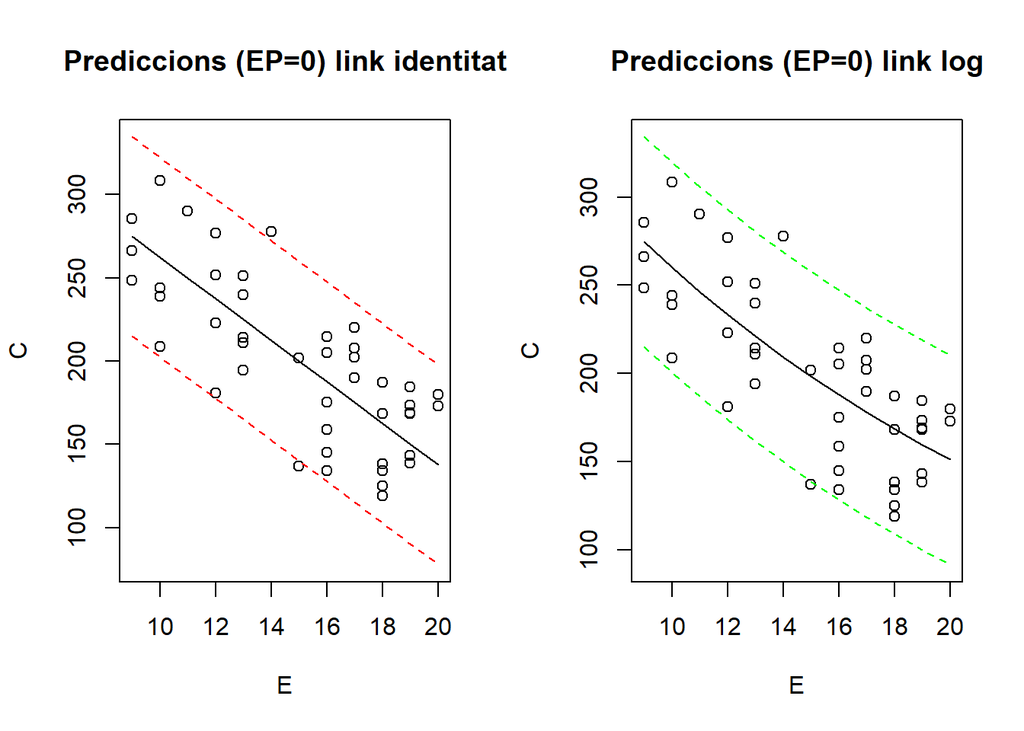

```r
##-- Valors a predir
E   <- 9:20
EP  <- 0
df  <- data.frame(E=E, EP=EP)
dd0 <- dd[dd$EP==0,]

##-- Prediccions link identitat
par(mfrow=c(1,2))
PP    <- predict(modg, df , type = "response")
disp  <- summary(modg)$dispersion
V     <- 1
ylim  <- range(PP) + c(-2,2) * sqrt(V*disp)
plot(C ~ E, dd0, ylim=ylim, main="Prediccions (EP=0) link identitat")
lines(E, PP)
lines(E, PP + 2 * sqrt(V*disp), col="red",lty=2)
lines(E, PP - 2 * sqrt(V*disp), col="red",lty=2)

##-- Prediccions link log
PP    <- predict(modg_log, df , type = "response")
disp  <- summary(modg_log)$dispersion
V     <- 1
ylim  <- range(PP) + c(-2,2) * sqrt(V*disp)
plot(C ~ E, dd0, ylim=ylim, main="Prediccions (EP=0) link log")
lines(E, PP)
lines(E, PP + 2 * sqrt(V*disp), col="green",lty=2)
lines(E, PP - 2 * sqrt(V*disp), col="green",lty=2)
```

### Altres families

La familia no l’hauriem de ajustar perquè sembla que no hi ha problemes de heteroscedasticitat. Igualment fem proves per veure com influeix. Mentenim el link “log”

```r
modg_nor <- glm(C ~ EP + E, dd, family = gaussian(link="log"))
modg_gam <- glm(C ~ EP + E, dd, family = Gamma(link="log"))
modg_iga <- glm(C ~ EP + E, dd, family = inverse.gaussian(link="log"))
```

Veiem el gràfic de residus versus valors predits de 3 families.

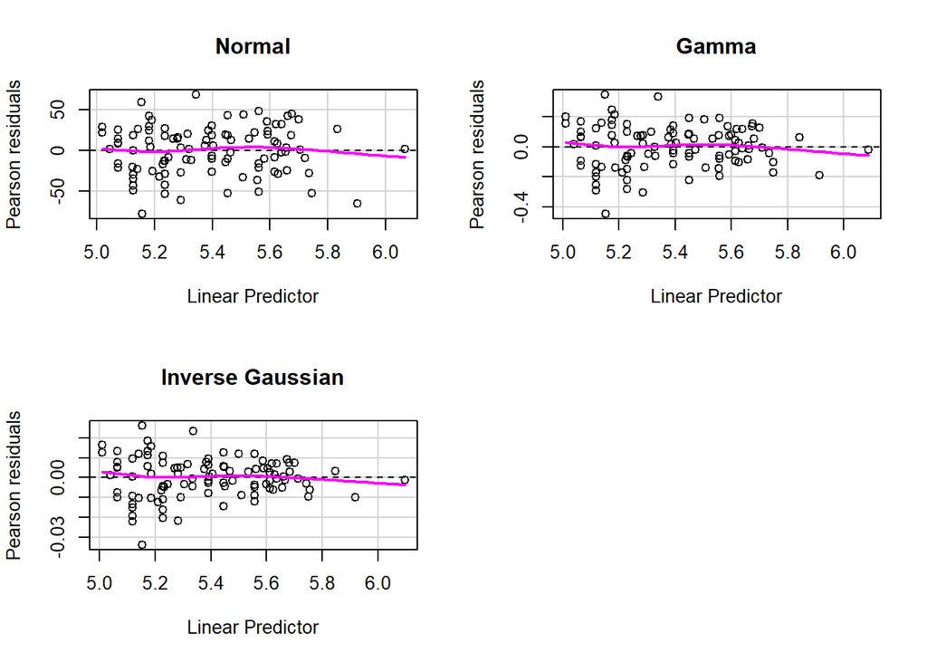

```r
par(mfrow=c(2,2))
residualPlot(modg_nor, main='Normal')
residualPlot(modg_gam, main='Gamma')
residualPlot(modg_iga, main='Inverse Gaussian')
```

Amb la familia Normal sembla que va millor. Comparem prediccions amb Gamma

**EP=0**

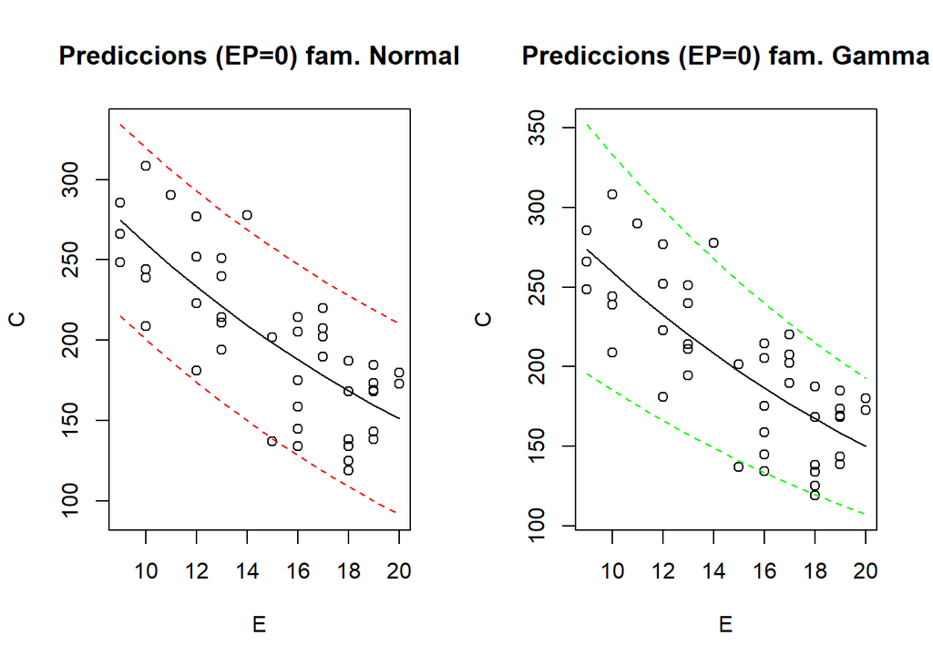

```r
##-- Prediccions familia Normal
par(mfrow=c(1,2))
PP    <- predict(modg_nor, df , type = "response")
disp  <- summary(modg_nor)$dispersion
V     <- 1
ylim  <- range(PP) + c(-2,2) * sqrt(V*disp)
plot(C ~ E, dd0, ylim=ylim, main="Prediccions (EP=0) fam. Normal")
lines(E, PP)
lines(E, PP + 2 * sqrt(V*disp), col="red",lty=2)
lines(E, PP - 2 * sqrt(V*disp), col="red",lty=2)

##-- Prediccions familia Gamma
PP     <- predict(modg_gam, df , type = "response")
disp   <- summary(modg_gam)$dispersion
V      <- PP^2 # La funcio de variància en la gamma és mu^2
ylim   <- range(c(PP - 2 * sqrt(V*disp), PP + 2 * sqrt(V*disp)))
plot(C ~ E, dd0, ylim=ylim, main="Prediccions (EP=0) fam. Gamma")
lines(E, PP)
lines(E, PP + 2 * sqrt(V*disp), col="green",lty=2)
lines(E, PP - 2 * sqrt(V*disp), col="green",lty=2)
```

Amb la familia Gamma, les bandes de predicció a les edats tempranes son massa folgades.